# **Pomysły na projekt**

## *Zainspirowanie się artykułami-odpowiedziami :*

### https://www.nature.com/articles/s42256-020-00254-2

ENG: Although the authors reported success in their attempt to determine markers of imminent mortality in their dataset, they used a small validation sample size and did not externally validate their model3. We have attempted, under various use cases, to validate their model using data from patients with COVID-19 treated in Northwell Health hospitals. We also attempted to recalibrate the primary branch of the proposed tree-based model based on our data to account for differences between our populations and health systems.

PL: Chociaż autorzy zgłosili sukces w próbie określenia markerów zbliżającej się śmiertelności w swoim zbiorze danych, zastosowali małą wielkość próby walidacyjnej i nie zweryfikowali zewnętrznie swojego modelu3. Podjęliśmy próbę, w różnych przypadkach użycia, walidacji ich modelu przy użyciu danych od pacjentów z COVID-19 leczonych w szpitalach Northwell Health. Podjęliśmy również próbę rekalibracji głównej gałęzi proponowanego modelu opartego na drzewach w oparciu o nasze dane, aby uwzględnić różnice między naszymi populacjami i systemami opieki zdrowotnej1.

Wytkniętą wadą modelu jest to, że powinien on mieć od razu wystarczającą wydajność predykcji, aby być użyteczny kliniczni, gdyż to że wyniki się coraz to bardziej poprawiają oznacza, że nie jest wystarczająco dobry.

Z tego co rozumiem to autorzy wzięli ten sam model i przetestowali go na większych danych, większym setcie uczącym i walidacyjnym i w efektcie wyszło im, że skuteczność poprawnego przewidywania śmierci to tylko 50%, co pokazuje, że model ten nie jest wystarczająco dobry

### https://www.nature.com/articles/s42256-020-00253-3

Tutaj nie ma nic ciekawego, mówią tylko, że używając tego naszego modelu 36% osób które powinno umrzeć faktycznie umarło, więc ten model trochę ssie. Jako możliwą przyczynę też wskazują inną genetykę (Szpital z Danii) i protokół przyjmowania i postępowania z pacjentami.

### https://www.nature.com/articles/s42256-020-00252-4

EN : As a result, we believe that different rules should be adapted to different stages of the illness. For example, a decision tree could be rebuilt in the ICU to predict the occurrence of death. Furthermore, death might not be the most appropriate outcome—worsening of the disease could be better. Another decision rule could be built for patients admitted to the emergency room to predict worsening, that is, the occurrence of severe or critical types of COVID (COS-COVID)4. Finally, as already mentioned by Yan et al., we agree that, for the development of more rigorous prediction models, collaboration and sharing of well-documented individual data for COVID-19 are needed. The predictors already identified, such as LDH, hs-CRP and lymphocyte counts, should be considered as candidate predictors for new models5.

PL: W rezultacie uważamy, że różne zasady powinny być dostosowane do różnych stadiów choroby. Na przykład drzewo decyzyjne można odbudować na OIOM-ie, aby przewidywać śmierć. Ponadto śmierć może nie być najwłaściwszym skutkiem - pogorszenie choroby mogłoby być lepsze. Inną regułę decyzyjną można by opracować dla pacjentów przyjmowanych na izbę przyjęć, aby przewidzieć pogorszenie, czyli wystąpienie ciężkich lub krytycznych typów COVID (COS-COVID) 4. Wreszcie, jak już wspomnieli Yan i wsp., Zgadzamy się, że do opracowania bardziej rygorystycznych modeli prognozowania potrzebna jest współpraca i udostępnianie dobrze udokumentowanych indywidualnych danych dotyczących COVID-19. Zidentyfikowane już predyktory, takie jak LDH, hs-CRP i liczba limfocytów, należy traktować jako potencjalne predyktory dla nowych modeli5.

Oni mają pomysł, żeby zmienić sposób predykcji. Jako nasz target uznawać nie śmierć, a pogorszenie się staniu zdrowia, wystąpienie powikłań, itd.

## *Jakieś inne :*

**Imputacja**

Dane które mamy są bardzo wybrakowane, moglibyśmy je uzupełnić jakąś imputacją w dla każdego pacjenta (problem, to jka wygląda sam data set dla pacjentów). Taka imputacja dałaby nam stany chwilowe wraz ze wsystkimi danymi (mogą być i pewnie będą niezgodne z rzeczywistością, ale jest szansa, że to magicznie poprawi wydajność).

**Wiek**

W artykule nie był uznany jako czynnik przebiegu choroby wiek pacjenta i moglibyśmy go także użyć przy uczneniu modelu. Mamy trochę szerszą wiedzę na temat koronawirusa i wiemy, że osoby starsze są bardziej na niego narażone więc to wykorzystajmy.

**Artykuł który popiera wiek i jego fragment:**

https://www.nature.com/articles/s41746-021-00383-x

ENG: Despite only relying on previously documented demographics and comorbidities, our models demonstrated similar performance to other prognostic models that require an assortment of symptoms, laboratory values, and images at the time of diagnosis or during the course of the illness. In general, we found age as the most important predictor of mortality in COVID-19 patients. A history of pneumonia, which is rarely asked in typical epidemiology studies, was one of the most important risk factors for predicting COVID-19 mortality. A history of diabetes with complications and cancer (breast and prostate) were notable risk factors for patients between the ages of 45 and 65 years. In patients aged 65–85 years, diseases that affect the pulmonary system, including interstitial lung disease, chronic obstructive pulmonary disease, lung cancer, and a smoking history, were important for predicting mortality. The ability to compute precise individual-level risk scores exclusively based on the EHR is crucial for effectively allocating and distributing resources, such as prioritizing vaccination among the general population.

PL: Pomimo oparcia się wyłącznie na wcześniej udokumentowanych danych demograficznych i chorobach współistniejących, nasze modele wykazały podobną wydajność do innych modeli prognostycznych, które wymagają zestawu objawów, wartości laboratoryjnych i obrazów w momencie diagnozy lub w trakcie przebiegu choroby. Ogólnie rzecz biorąc, uznaliśmy wiek za najważniejszy predyktor śmiertelności u pacjentów z COVID-19. Historia zapalenia płuc, które rzadko jest zadawane w typowych badaniach epidemiologicznych, była jednym z najważniejszych czynników ryzyka w przewidywaniu śmiertelności z powodu COVID-19. Historia cukrzycy z powikłaniami i rakiem (piersi i prostaty) była istotnymi czynnikami ryzyka dla pacjentów w wieku od 45 do 65 lat. U pacjentów w wieku 65–85 lat choroby wpływające na układ oddechowy, w tym śródmiąższowa choroba płuc, przewlekła obturacyjna choroba płuc, rak płuc i palenie w wywiadzie, były ważne w przewidywaniu śmiertelności. Zdolność do obliczania dokładnych ocen ryzyka na poziomie indywidualnym wyłącznie na podstawie EHR ma kluczowe znaczenie dla skutecznego przydzielania i dystrybucji zasobów, takich jak ustalanie priorytetów szczepień wśród ogólnej populacji.

**Kolejne ważne współczynniki**

Artykuł: https://www.nature.com/articles/s41467-020-18297-9

Link do wizulizacji z artykułu, która przedstiawia najważniejsze czynniki użytew ich własnym modelu predykcyjnym:

https://media.springernature.com/lw685/springer-static/image/art%3A10.1038%2Fs41467-020-18297-9/MediaObjects/41467_2020_18297_Fig1_HTML.png?as=webp

Z powyższego wynika, że ważnymi zmiennymi są m.in. wiek(jest), cadiovascular diseases (nie ma), C reactive protein (jest), Chloride (jest), Hospitalization time(da się zdobyć) oraz Albumin(jest).

Całości nie czytałem, ale jak ktoś chce to może się zagłębić w temat. Artykuł wygląda jakby miał naprawde solidnie opisany model, ale też na pewno nie jest tak prosty w zrozumieniu jak to co mamy w naszym.

```python
# -- coding:utf-8 --
import os
from os.path import join as pjoin
import numpy as np
import pandas as pd
import matplotlib.pyplot as plt
plt.rcParams['font.sans-serif'] = ['SimHei']
plt.rcParams['axes.unicode_minus'] = False

from sklearn.metrics import confusion_matrix, accuracy_score, f1_score, classification_report


# 常用参数
top3_feats_cols = ['Lactate dehydrogenase', 'High sensitivity C-reactive protein', '(%)lymphocyte']
in_out_time_cols = ['Admission time', '出院时间']


def is_number(s):
    if s is None:
        s = np.nan

    try:
        float(s)
        return True
    except ValueError:
        pass

    try:
        import unicodedata
        unicodedata.numeric(s)
        return True
    except (TypeError, ValueError):
        pass

    return False


def read(path: str, usecols=None, is_ts='infer'):
    """读取处理后的数据
    合并 parquet, csv, excel 三种格式文件的读取函数

    :param path: 文件路径，必须是 parquet 或 csv 或 excel 文件
    :param usecols: 选取的列。与 pandas 接口不同，此处进行了简化，无需写索引列
    :param is_ts: 是否为时间序列。可选值：'infer', True, False
    :return: 读取的 DateFrame 数据
    """
    # 设置索引
    if is_ts == 'infer':
        index_col = [0, 1] if os.path.split(path)[1].startswith('time_series') else [0]
    elif is_ts is True:
        index_col = [0, 1]
    elif is_ts is False:
        index_col = [0]
    else:
        raise Exception('is_ts 参数错误')

    # 读取数据
    if path.endswith('.parquet'):
        data = pd.read_parquet(path)
    elif path.endswith('.csv'):
        try:
            data = pd.read_csv(path, index_col=index_col, encoding='gb18030')
        except UnicodeDecodeError:
            data = pd.read_csv(path, index_col=index_col, encoding='utf-8')
        except:
            raise
    elif path.endswith('.xlsx'):
        data = pd.read_excel(path, index_col=index_col, engine='openpyxl')
    else:
        raise Exception('文件类型错误')

    # 提取指定列
    if usecols is not None:
        data = data[usecols]

    return data


def merge_data_by_sliding_window(data, n_days=1, dropna=True, subset=None, time_form='diff'):
    """滑窗合并数据

    :param data: 时间序列数据，一级行索引为 PATIENT_ID, 二级行索引为 RE_DATE
    :param n_days: 窗口长度
    :param dropna: 滑窗合并后还缺失的是否删掉
    :param subset: pd.DataFrame().dropna() 参数                                                   Note: 新参数!
    :param time_form: 返回数据的时间索引，'diff' or 'timestamp'
    :return: 合并后的数据，一级行索引为 PATIENT_ID, 二级行索引为 t_diff or RE_DATE, 取决于"time_form"
    """
    #根据PATIENT_ID排序
    data = data.reset_index(level=1)
    # dt.normalize() 取出院时间的天数
    # 距离出院时长        Note: 去掉了出院时间和检测时间的时分秒，因为我觉得以 00:00:00 为分界点更合适
    t_diff = data['Discharge time'].dt.normalize() - data['RE_DATE'].dt.normalize()
    # 滑窗取整的依据。即nn_days天内的会取整成为同一个数值，后面通过groupby方法分组
    data['t_diff'] = t_diff.dt.days.values // n_days * n_days
    #
    data = data.set_index('t_diff', append=True)

    # 滑窗合并。对['PATIENT_ID', 't_diff']groupby，相当于双循环。遍历所有病人与病人的所有窗口
    # 因为之前对data排序，因此每个病人t_diff会是从大到小的排序,ffill()是向上一行插值，因此相当于是向旧日期插值
    # last()是每一组取最后一行，因此即取每个病人对应窗口的最后一次数据，（也一定是最全的）。
    # last(）自带排序。取完last后会按照索引升序排列
    data = (
        data
        .groupby(['PATIENT_ID', 't_diff']).ffill()
        .groupby(['PATIENT_ID', 't_diff']).last()
    )
    # 去掉缺失样本
    if dropna:
        data = data.dropna(subset=subset)         # Note: 这里对缺失值进行了 dropna(), 而不是 fillna(-1)

    # 更新二级索引。（其实timestamp在本论文的中没用到）
    if time_form == 'timestamp':
        data = (
            data
            .reset_index(level=1, drop=True)
            .set_index('RE_DATE', append=True)
        )
    elif time_form == 'diff':
        data = data.drop(columns=['RE_DATE'])

    return data


def score_form(x: np.array):
    """打分表预测
    example: pred, score = score_form(df[['乳酸脱氢酶', '淋巴细胞(%)', '超敏C反应蛋白']].values)

    :param x: 列顺序：['乳酸脱氢酶', '淋巴细胞(%)', '超敏C反应蛋白']
    :return: 预测类别及最后得分
    """
    x = x.copy()

    # 乳酸脱氢酶
    x[:, 0] = pd.cut(
        x[:, 0],
        [-2, 107, 159, 210, 262, 313, 365, 416, 467, 519, 570, 622, 673, 724, 776, 827, 1e5],
        labels=list(range(-5, 11))
    )

    # 淋巴细胞(%)
    x[:, 1] = pd.cut(
        x[:, 1],
        [-2, 1.19, 3.12, 5.05, 6.98, 8.91, 10.84, 12.77, 14.7, 16.62, 18.55, 20.48, 22.41, 24.34, 1e5],
        labels=list(range(8, -6, -1))
    )

    # 超敏C反应蛋白
    x[:, 2] = pd.cut(
        x[:, 2],
        [-2, 19.85, 41.2, 62.54, 83.88, 1e5],
        labels=list(range(-1, 4))
    )

    # 统分
    total_score = x.sum(axis=1)

    # 1 分为临界点，大于 1 分死亡，小于 1 分治愈
    pred = (total_score > 1).astype(int)
    return pred, total_score


def decision_tree(x: pd.Series):
    """正文中的决策树
    example: df.apply(decision_tree, axis=1)

    :param x: 单个样本，['乳酸脱氢酶', 'High sensitivity C-reactive protein', '(%)lymphocyte']
    :return: 0: 治愈, 1: 死亡
    """
    if x['Lactate dehydrogenase'] >= 365:
        return 1

    if x['High sensitivity C-reactive protein'] < 41.2:
        return 0

    if x['(%)lymphocyte'] > 14.7:
        return 0
    else:
        return 1


def get_time_in_advance_of_predict(data):
    """提前预测正确的天数

    :param data: 时间序列数据，一级行索引为 PATIENT_ID, 二级行索引为 t_diff
    :return: pd.Series, index: PATIENT_ID, values: 提前预测正确的天数
    """
    # 由于python的机制，用copy新建一个data，不然会修改原dat
    data = data.copy()
    # 在data 这个dataframe中新建一列right，数值是判定是否正确
    data['right'] = data['pred'] == data['outcome']
    # 新建一个空列表，用于存储提前预测的正确的天数
    time_advance = []
    # data.index.remove_unused_levels().levels[0]表示的是病人id的list，即遍历所有病人
    for id_ in data.index.remove_unused_levels().levels[0]:
        # 因为病人id是一级索引，loc方法取出该病人对应的所有数据（可能有多条）
        d = data.loc[id_]
        # 如果病人只有一条数据单数据
        if len(d) == 1:
            if d.iloc[0]['right']:
                # 将预测对存入time_advance，分别为病人的id，正确的天数，出院的方式
                time_advance.append([id_, d.iloc[0].name, d['outcome'].iat[0]])
            continue

        # 多数据 Step1: 预测错
        if not d.iloc[0]['right']:
            continue

        # 多数据 Step2: 全对
        if d['right'].all():
            # 将预测对存入time_advance，分别为病人的id，正确的天数，出院的方式
            time_advance.append([id_, d.iloc[-1].name, d['outcome'].iat[0]])
            continue

        # 多数据 Step3: 部分对
        for i in range(len(d)):
            if d.iloc[i]['right']:
                continue
            else:
                # 将预测对存入time_advance，分别为病人的id，正确的天数，出院的方式
                time_advance.append([id_, d.iloc[i-1].name, d['outcome'].iat[0]])
                break

    # 将time_advance存成DataFrame
    time_advance = pd.DataFrame(time_advance, columns=['PATIENT_ID', 'time_advance', 'outcome'])
    time_advance = time_advance.set_index('PATIENT_ID')
    return time_advance


class Metrics:
    def __init__(self, report=None, acc=None, f1=None, conf_mat=None):
        self.y_trues  = []
        self.y_preds  = []

        # list or None. 'every': 每折都打印; 'overall': 打印总体的
        if isinstance(report, list):
            self.report = report
        else:
            self.report = [report]

        if isinstance(acc, list):
            self.acc = acc
        else:
            self.acc = [acc]

        if isinstance(f1, list):
            self.f1 = f1
        else:
            self.f1 = [f1]

        if isinstance(conf_mat, list):
            self.conf_mat = conf_mat
        else:
            self.conf_mat = [conf_mat]

    def record(self, y_true, y_pred):
        self.y_trues.append(y_true)
        self.y_preds.append(y_pred)
        return self

    def clear(self):
        self.y_trues = []
        self.y_preds = []
        return self

    def print_metrics(self):
        """打印指标

        :param report:
        :param acc:
        :param f1:
        :param conf_mat:
        :return:
        """
        # Loop: 'every'
        acc_values, f1_values = [], []
        single_fold = True if len(self.y_trues) == 1 else False
        for i, (y_true, y_pred) in enumerate(zip(self.y_trues, self.y_preds)):
            assert (y_true.ndim == 1) and (y_pred.ndim == 1)
            print(f'\n======================== 第 {i+1} 折指标 ========================>')

            # Classification_report
            if (self.report is not None) and ('every' in self.report):
                print(classification_report(y_true, y_pred))

            # Accuracy_score
            a_v = accuracy_score(y_true, y_pred)
            acc_values.append(a_v)
            if (self.acc is not None) and ('every' in self.acc):
                print(f"accuracy: {a_v:.05f}")

            # F1_score
            f1_v = f1_score(y_true, y_pred, average='macro')
            f1_values.append(f1_v)
            if (self.f1 is not None) and ('every' in self.f1):
                print(f"F1: {f1_v:.05f}")

            # Confusion_matrix
            if (self.conf_mat is not None) and ('every' in self.conf_mat):
                print(f"混淆矩阵：\n{confusion_matrix(y_true, y_pred)}")

        # 'Overall'
        print('\n======================== 总体指标 ========================>')
        y_true = np.hstack(self.y_trues)
        y_pred = np.hstack(self.y_preds)

        # Classification_report
        if (self.report is not None) and ('overall' in self.report):
            print(classification_report(y_true, y_pred))

        # Accuracy_score
        if (self.acc is not None) and ('overall' in self.acc):
            if single_fold:
                print(f"accuracy：\t{acc_values[0]: .04f}")
            else:
                print(f"accuracy：\t{np.mean(acc_values): .04f} / {'  '.join([str(a_v.round(2)) for a_v in acc_values])}")

        # F1_score
        if (self.f1 is not None) and ('overall' in self.f1):
            if single_fold:
                print(f"F1-score：\t{f1_values[0]: .04f}")
            else:
                print(f"F1 均值：\t{np.mean(f1_values): .04f} / {'  '.join([str(f1_v.round(2)) for f1_v in f1_values])}")

        # Confusion_matrix
        if (self.conf_mat is not None) and ('overall' in self.conf_mat):
            print(f"混淆矩阵：\n{confusion_matrix(y_true, y_pred)}")


def feat_zh2en(data):
    """特征名中文转英文"""
    feats_zh = data.columns

    # 显示哪些列没有中英翻译
    feats_map = pd.read_excel('data/raw_data/特征名_zh2en/特征名_zh2en.xlsx', index_col=0)['en']
    out_of_map = set(feats_zh) - set(feats_map.index)
    print(f"缺少翻译的特征：{out_of_map}")

    # 开始翻译
    feats_map = feats_map.to_dict()
    data = data.rename(columns=feats_map)
    return data


def concat_data(data375: pd.DataFrame, data110: pd.DataFrame):
    """整合 375 + 110
    因为 PATIENT_ID 都从 1 开始，所以整合时需要调整，避免重合

    :param data375:
    :param data110:
    :return:
    """
    data110 = data110.reset_index()
    data110['PATIENT_ID'] += 375
    data110 = data110.set_index(['PATIENT_ID', 'RE_DATE'])
    data = data375.append(data110)
    return data
```

```python
import os
from os.path import join as pjoin
import numpy as np
import pandas as pd
import matplotlib.pyplot as plt
plt.rcParams['font.sans-serif'] = ['SimHei']
plt.rcParams['axes.unicode_minus'] = False

from sklearn.metrics import confusion_matrix, accuracy_score, f1_score, classification_report
from sklearn.experimental import enable_iterative_imputer
from sklearn.impute import IterativeImputer
import pandas as pd
import numpy as np
import os
from os.path import join as pjoin

#from utils import is_number

import matplotlib.pyplot as plt
import seaborn as sns
import warnings

import xgboost as xgb
from sklearn.model_selection import StratifiedKFold
from sklearn.model_selection import train_test_split
from sklearn.metrics import f1_score
from matplotlib import pyplot as plt
from matplotlib.colors import ListedColormap

from sklearn import metrics
from sklearn.metrics import classification_report
from sklearn import preprocessing

from mpl_toolkits.mplot3d import Axes3D
from sklearn.metrics import roc_auc_score
from sklearn.metrics import roc_curve, auc
import matplotlib as mpl
```

```python
def my_read_train_data(path_train):
    data_df = pd.read_excel(path_train, encoding='gbk', index_col=[0, 1],engine='openpyxl')  # train_sample_375_v2 train_sample_351_v4
    data_df = data_df.groupby('PATIENT_ID').last()
    lable = data_df['outcome'].values
    data_df = data_df.drop(['outcome', 'Admission time', 'Discharge time'], axis=1)
    data_df['Type2'] = lable
    data_df = data_df.applymap(lambda x: x.replace('>', '').replace('<', '') if isinstance(x, str) else x)
    data_df = data_df.applymap(lambda x: x if is_number(x) else -1)
    data_df = data_df.astype(float)

    return data_df
```

```python
my_df=my_read_train_data('./data/time_series_375_prerpocess_en.xlsx')
#my_df2=my_read_train_data('./data/time_series_test_110_preprocess_en.xlsx')
my_df
```

| PATIENT_ID | age | gender | Hypersensitive cardiac troponinI | hemoglobin | Serum chloride | Prothrombin time | procalcitonin | eosinophils(%) | Interleukin 2 receptor | Alkaline phosphatase | ... | Activation of partial thromboplastin time | High sensitivity C-reactive protein | HIV antibody quantification | serum sodium | thrombocytocrit | ESR | glutamic-pyruvic transaminase | eGFR | creatinine | Type2 |
| --- | --- | --- | --- | --- | --- | --- | --- | --- | --- | --- | --- | --- | --- | --- | --- | --- | --- | --- | --- | --- | --- |
| 1 | 73.0 | 1.0 | 19.9 | 131.0 | 100.0 | 12.4 | 0.09 | 1.7 | NaN | 71.0 | ... | 38.9 | 2.6 | 0.09 | 142.7 | 0.16 | 41.0 | 30.0 | 74.7 | 88.0 | 0.0 |
| 2 | 61.0 | 1.0 | 1.9 | 149.0 | 98.1 | 12.3 | 0.09 | 0.1 | 441.0 | 45.0 | ... | 36.0 | 27.4 | NaN | 137.4 | 0.27 | 40.0 | 22.0 | 94.6 | 74.0 | 0.0 |
| 3 | 70.0 | 2.0 | NaN | 126.0 | 102.2 | 13.6 | 0.06 | 0.1 | 591.0 | 69.0 | ... | 34.8 | 3.6 | 0.10 | 143.2 | 0.23 | 29.0 | 67.0 | 84.6 | 64.0 | 0.0 |
| 4 | 74.0 | 1.0 | 4.8 | 103.0 | 103.1 | 16.3 | 0.38 | 2.5 | NaN | 79.0 | ... | NaN | 14.5 | 0.11 | 144.2 | 0.27 | 72.0 | 26.0 | 74.2 | 88.0 | 0.0 |
| 5 | 29.0 | 2.0 | 5.6 | 130.0 | 102.2 | 14.6 | 0.02 | 3.0 | 258.0 | 84.0 | ... | NaN | 0.8 | 0.08 | 143.6 | 0.36 | 11.0 | 18.0 | 122.8 | 54.0 | 0.0 |
| ... | ... | ... | ... | ... | ... | ... | ... | ... | ... | ... | ... | ... | ... | ... | ... | ... | ... | ... | ... | ... | ... |
| 371 | 63.0 | 1.0 | 1741.5 | 143.0 | 95.7 | 14.4 | 1.51 | 0.0 | 758.0 | 65.0 | ... | 43.8 | 152.0 | NaN | 135.8 | 0.16 | 19.0 | 31.0 | 88.6 | 81.0 | 1.0 |
| 372 | 79.0 | 1.0 | 45.0 | 102.0 | 119.8 | 29.5 | 1.14 | 0.2 | 1833.0 | 180.0 | ... | 55.3 | 177.6 | 0.06 | 155.4 | 0.07 | 93.0 | 121.0 | 12.9 | 364.0 | 1.0 |
| 373 | 61.0 | 2.0 | 124.8 | 100.0 | 102.6 | 14.9 | 0.56 | 0.1 | NaN | 141.0 | ... | 36.7 | 205.8 | NaN | 141.6 | 0.18 | NaN | 9.0 | 101.3 | 47.0 | 1.0 |
| 374 | 33.0 | 1.0 | 372.4 | 121.0 | 128.2 | 30.2 | NaN | 0.0 | 2634.0 | 143.0 | ... | 44.9 | 61.7 | 0.09 | 164.7 | 0.13 | 19.0 | 1508.0 | 69.4 | 118.0 | 1.0 |
| 375 | 68.0 | 1.0 | 84.9 | 155.0 | 105.2 | 17.9 | 2.69 | 0.0 | 1524.0 | 94.0 | ... | 35.8 | 267.0 | 0.08 | 139.3 | 0.24 | 39.0 | 17.0 | 88.6 | 77.0 | 1.0 |

375 rows × 77 columns

```
findfont: Font family ['sans-serif'] not found. Falling back to DejaVu Sans.
```

[figure not shown]

```python
plt.figure(figsize=(26,13))
df_num_cor=my_df.iloc[:,0:80]
c= df_num_cor.corr()
sns.heatmap(c,cmap='PRGn',annot=True)
```

```python
my_df.info()
```

```
<class 'pandas.core.frame.DataFrame'>
Int64Index: 375 entries, 1 to 375
Data columns (total 77 columns):
 #   Column                                                         Non-Null Count  Dtype
---  ------                                                         --------------  -----
 0   age                                                            375 non-null    float64
 1   gender                                                         375 non-null    float64
 2   Hypersensitive cardiac troponinI                               287 non-null    float64
 3   hemoglobin                                                     356 non-null    float64
 4   Serum chloride                                                 354 non-null    float64
 5   Prothrombin time                                               352 non-null    float64
 6   procalcitonin                                                  313 non-null    float64
 7   eosinophils(%)                                                 356 non-null    float64
 8   Interleukin 2 receptor                                         216 non-null    float64
 9   Alkaline phosphatase                                           356 non-null    float64
```

[output cut: 69 more lines]

```python
my_df.isnull().sum().to_numpy()
```

```
array([  0,   0,  88,  19,  21,  23,  62,  19, 159,  19,  19,  19, 160,
        19,  19,  19, 173, 159,  20,  25,  19,  19, 100,  23, 100,  19,
        19,  18, 159,  19,  77, 159,  19,  19, 143,  18,  19,  22,  21,
        24,  19,  19,  29, 162,  25,  77,  19, 100,  33,  19,  19,  19,
        19,  21, 108,  19,  29, 157, 173,  19,  29,  19,  19,  23,  19,
       157,  19,  77,  22, 101,  21,  29,  87,  19,  19,  19,   0],
      dtype=int64)
```

```python
important_features_df=my_df.iloc[:,[0,4,10,33,55,68,76]]
#important_features_df2=my_df2.iloc[:,[0,4,10,68,76]]
important_features_df
```

| PATIENT_ID | age | Serum chloride | albumin | lymphocyte count | Lactate dehydrogenase | High sensitivity C-reactive protein | Type2 |
| --- | --- | --- | --- | --- | --- | --- | --- |
| 1 | 73.0 | 100.0 | 37.6 | 2.50 | 206.0 | 2.6 | 0.0 |
| 2 | 61.0 | 98.1 | 37.2 | 0.95 | 282.0 | 27.4 | 0.0 |
| 3 | 70.0 | 102.2 | 38.4 | 2.10 | 226.0 | 3.6 | 0.0 |
| 4 | 74.0 | 103.1 | 34.1 | 1.12 | 249.0 | 14.5 | 0.0 |
| 5 | 29.0 | 102.2 | 39.5 | 1.88 | 179.0 | 0.8 | 0.0 |
| ... | ... | ... | ... | ... | ... | ... | ... |
| 371 | 63.0 | 95.7 | 30.7 | 0.77 | 573.0 | 152.0 | 1.0 |
| 372 | 79.0 | 119.8 | 16.7 | 0.17 | 607.0 | 177.6 | 1.0 |
| 373 | 61.0 | 102.6 | 23.9 | 0.76 | 702.0 | 205.8 | 1.0 |
| 374 | 33.0 | 128.2 | 27.4 | 0.33 | 1867.0 | 61.7 | 1.0 |
| 375 | 68.0 | 105.2 | 21.3 | 0.55 | 783.0 | 267.0 | 1.0 |

375 rows × 7 columns

```python
important_features_df.isnull().sum()
```

```
age                                     0
Serum chloride                         21
albumin                                19
lymphocyte count                       19
Lactate dehydrogenase                  19
High sensitivity C-reactive protein    22
Type2                                   0
dtype: int64
```

```python
from sklearn.experimental import enable_iterative_imputer
from sklearn.impute import IterativeImputer
```

```python
imp = IterativeImputer(random_state=0, n_nearest_features=10)
important_features_df_2=imp.fit_transform(important_features_df)
important_features_df_2=pd.DataFrame(important_features_df_2, columns=['age','Serum chloride','albumin','lymphocyte count','Lactate dehydrogenase','High sensitivity C-reactive protein','Type2'])
#important_features_df2_2=imp.fit_transform(important_features_df2)
#important_features_df2_2=pd.DataFrame(important_features_df2_2, columns=['age','Serum chloride','albumin','High sensitivity C-reactive protein','Type2'])
important_features_df_2
```

|  | age | Serum chloride | albumin | lymphocyte count | Lactate dehydrogenase | High sensitivity C-reactive protein | Type2 |
| --- | --- | --- | --- | --- | --- | --- | --- |
| 0 | 73.0 | 100.0 | 37.6 | 2.50 | 206.0 | 2.6 | 0.0 |
| 1 | 61.0 | 98.1 | 37.2 | 0.95 | 282.0 | 27.4 | 0.0 |
| 2 | 70.0 | 102.2 | 38.4 | 2.10 | 226.0 | 3.6 | 0.0 |
| 3 | 74.0 | 103.1 | 34.1 | 1.12 | 249.0 | 14.5 | 0.0 |
| 4 | 29.0 | 102.2 | 39.5 | 1.88 | 179.0 | 0.8 | 0.0 |
| ... | ... | ... | ... | ... | ... | ... | ... |
| 370 | 63.0 | 95.7 | 30.7 | 0.77 | 573.0 | 152.0 | 1.0 |
| 371 | 79.0 | 119.8 | 16.7 | 0.17 | 607.0 | 177.6 | 1.0 |
| 372 | 61.0 | 102.6 | 23.9 | 0.76 | 702.0 | 205.8 | 1.0 |
| 373 | 33.0 | 128.2 | 27.4 | 0.33 | 1867.0 | 61.7 | 1.0 |
| 374 | 68.0 | 105.2 | 21.3 | 0.55 | 783.0 | 267.0 | 1.0 |

375 rows × 7 columns

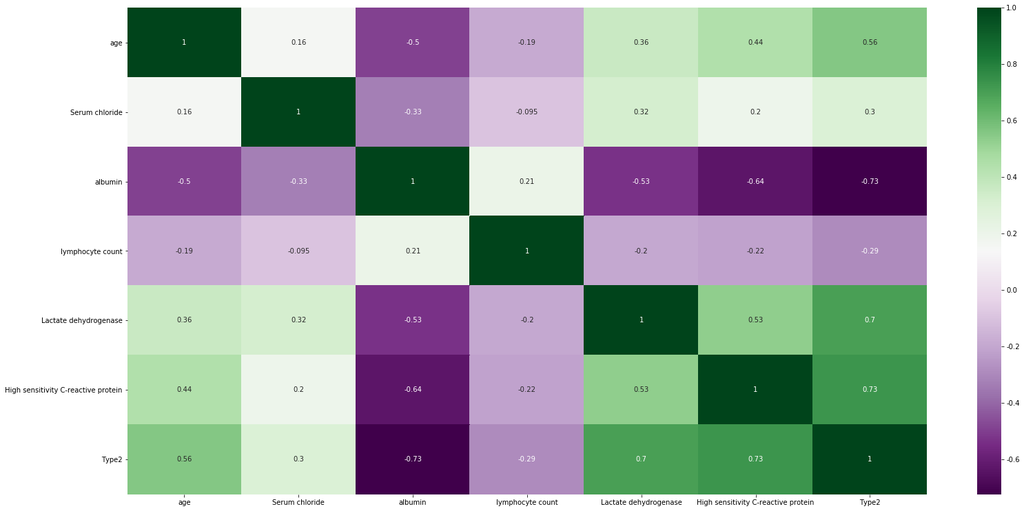

```python
plt.figure(figsize=(26,13))
df_num_cor=important_features_df_2.iloc[:,0:7]
c= df_num_cor.corr()
sns.heatmap(c,cmap='PRGn',annot=True)
```

```python
important_features_df_2.isnull().sum()
```

```
age                                    0
Serum chloride                         0
albumin                                0
lymphocyte count                       0
Lactate dehydrogenase                  0
High sensitivity C-reactive protein    0
Type2                                  0
dtype: int64
```

```python
from sklearn.ensemble import GradientBoostingClassifier
from sklearn.pipeline import Pipeline
from sklearn.ensemble import GradientBoostingClassifier
from sklearn.pipeline import Pipeline
from sklearn.ensemble import AdaBoostClassifier
from matplotlib import pyplot as plt
x_train, x_test, y_train, y_test = train_test_split(important_features_df_2.iloc[:,[0,2,4,5]],important_features_df_2.iloc[:,6], random_state=997)
#x_train=important_features_df_2.iloc[:,:3]
#x_test =important_features_df2_2.iloc[:,:3]
#y_train=important_features_df_2.iloc[:,4]
#y_test = important_features_df2_2.iloc[:,4]

clf = GradientBoostingClassifier(n_estimators=75, learning_rate=.05,
    max_depth=3, random_state=997)
clf1 = AdaBoostClassifier(random_state=1,learning_rate=0.15,algorithm ='SAMME.R')
```

```python
clf.fit(x_train,y_train)
prediction_test=clf.predict(x_test)
print(prediction_test)
clf.score(x_test,y_test)
```

```
[0. 0. 1. 0. 0. 0. 0. 0. 1. 1. 1. 0. 1. 0. 1. 0. 1. 0. 0. 0. 0. 0. 1. 0.
 1. 1. 1. 0. 0. 1. 1. 0. 0. 0. 1. 0. 0. 1. 1. 0. 1. 1. 0. 0. 0. 1. 0. 1.
 1. 1. 0. 0. 1. 0. 0. 1. 0. 1. 1. 0. 1. 1. 0. 1. 0. 1. 1. 0. 1. 1. 1. 1.
 0. 0. 0. 1. 0. 1. 0. 0. 1. 1. 1. 1. 1. 1. 1. 0. 0. 0. 1. 0. 0. 0.]
```

```
1.0
```

```python
prediction_train=clf.predict(x_train)
print(prediction_train)
clf.score(x_train,y_train)
```

```
[1. 1. 1. 0. 1. 1. 0. 1. 1. 1. 1. 0. 0. 0. 1. 1. 0. 0. 0. 0. 1. 0. 0. 1.
 0. 1. 0. 1. 1. 1. 0. 0. 0. 0. 0. 1. 1. 1. 1. 0. 0. 1. 1. 1. 0. 1. 1. 1.
 0. 1. 0. 1. 0. 0. 1. 0. 0. 0. 1. 1. 1. 0. 1. 1. 0. 0. 0. 1. 0. 0. 0. 0.
 0. 1. 0. 0. 0. 1. 0. 0. 0. 1. 1. 1. 0. 0. 1. 0. 1. 1. 1. 0. 1. 1. 0. 1.
 0. 1. 1. 1. 0. 1. 1. 1. 1. 1. 0. 0. 0. 1. 1. 1. 0. 0. 1. 1. 0. 1. 0. 1.
 0. 1. 0. 0. 0. 0. 0. 0. 0. 0. 1. 0. 1. 0. 0. 0. 1. 0. 1. 1. 1. 1. 1. 0.
 1. 1. 1. 1. 0. 0. 1. 0. 0. 0. 0. 0. 0. 0. 1. 1. 1. 1. 0. 1. 1. 1. 0. 0.
 0. 1. 1. 0. 0. 0. 1. 0. 0. 1. 0. 1. 0. 0. 1. 1. 0. 0. 0. 0. 1. 0. 0. 1.
 1. 0. 1. 1. 0. 1. 1. 0. 0. 1. 1. 0. 1. 1. 1. 1. 0. 0. 1. 0. 0. 0. 0. 0.
 0. 0. 0. 0. 0. 0. 0. 1. 1. 0. 1. 0. 1. 0. 0. 0. 1. 0. 0. 0. 1. 0. 1. 0.
 0. 0. 0. 1. 1. 0. 0. 0. 0. 1. 1. 0. 1. 0. 0. 1. 1. 1. 0. 0. 1. 1. 0. 1.
 1. 0. 0. 1. 0. 1. 1. 0. 0. 1. 0. 1. 0. 1. 1. 0. 0.]
```

```
0.9928825622775801
```

```python
from sklearn import metrics
print(metrics.classification_report(y_test, prediction_test))
```

```
              precision    recall  f1-score   support

         0.0       1.00      1.00      1.00        49
         1.0       1.00      1.00      1.00        45

    accuracy                           1.00        94
   macro avg       1.00      1.00      1.00        94
weighted avg       1.00      1.00      1.00        94
```

```python
clf1.fit(x_train,y_train)
prediction_test=clf1.predict(x_test)
prediction_train=clf1.predict(x_train)
print(prediction_test)
clf1.score(x_test,y_test)
```

```
[0. 0. 1. 0. 0. 0. 0. 0. 1. 1. 1. 0. 1. 0. 1. 0. 1. 0. 0. 0. 0. 0. 1. 0.
 1. 1. 1. 0. 0. 1. 1. 0. 0. 0. 1. 0. 0. 1. 1. 0. 1. 1. 0. 0. 0. 1. 0. 1.
 0. 1. 0. 0. 1. 0. 0. 1. 0. 1. 1. 0. 1. 1. 0. 1. 0. 1. 1. 0. 1. 1. 1. 1.
 0. 0. 0. 0. 0. 1. 0. 1. 1. 1. 1. 1. 1. 1. 1. 0. 0. 0. 1. 0. 0. 0.]
```

```
0.9680851063829787
```

```python
from sklearn import metrics
print(metrics.classification_report(y_test, prediction_test))
```

```
              precision    recall  f1-score   support

         0.0       0.96      0.98      0.97        49
         1.0       0.98      0.96      0.97        45

    accuracy                           0.97        94
   macro avg       0.97      0.97      0.97        94
weighted avg       0.97      0.97      0.97        94
```

```python
print(metrics.classification_report(y_train, prediction_train))
```

```
              precision    recall  f1-score   support

         0.0       1.00      0.99      0.99       152
         1.0       0.98      1.00      0.99       129

    accuracy                           0.99       281
   macro avg       0.99      0.99      0.99       281
weighted avg       0.99      0.99      0.99       281
```

```python
from sklearn.model_selection import cross_validate
print('Kroswalidacja dla GradientBoosting')
print(np.mean(cross_validate(clf, x_test, y_test, cv=20, scoring='accuracy').get('test_score')))
print('Kroswalidacja dla AdaBoost')
print(np.mean(cross_validate(clf1, x_test, y_test, cv=20, scoring='accuracy').get('test_score')))
```

```
Kroswalidacja dla GradientBoosting
0.9791666666666667
Kroswalidacja dla AdaBoost
0.9583333333333334
```